# Credit EDA assignment

```python
##observation: Female is more taking canceled , more facing approved and more refused
#but in male is the average in every category
```

```python
##analysis on NAME_INCOME_TYPE
```

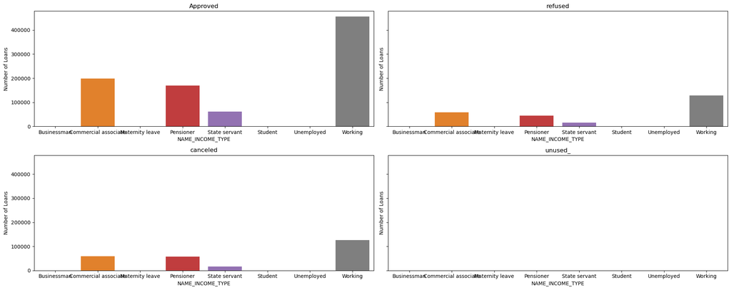

```python
fig,((ax1,ax2),(ax3,ax4)) = plt.subplots(nrows=2,ncols=2,figsize=(20,8),sharey=True)
ax1=sns.countplot(ax=ax1,data=approved_df,x='NAME_INCOME_TYPE')
ax1.set_title('Approved')
ax1.set_xlabel('NAME_INCOME_TYPE')
ax1.set_ylabel('Number of Loans')
ax2=sns.countplot(ax=ax2,data=refused_df,x='NAME_INCOME_TYPE')
ax2.set_title('refused')
ax2.set_xlabel('NAME_INCOME_TYPE')
ax2.set_ylabel('Number of Loans')
ax3=sns.countplot(ax=ax3,data=canceled_df,x='NAME_INCOME_TYPE')
ax3.set_title('canceled')
ax3.set_xlabel('NAME_INCOME_TYPE')
ax3.set_ylabel('Number of Loans')
ax4=sns.countplot(ax=ax4,data=unused_df,x='NAME_INCOME_TYPE')
ax4.set_title('unused_')
ax4.set_xlabel('NAME_INCOME_TYPE')
ax4.set_ylabel('Number of Loans')
plt.tight_layout()
plt.show()
```

```python
##working people take more loans than other and commercial people also take more loans
```

```python
##NAME_EDUCATION_TYPE
```

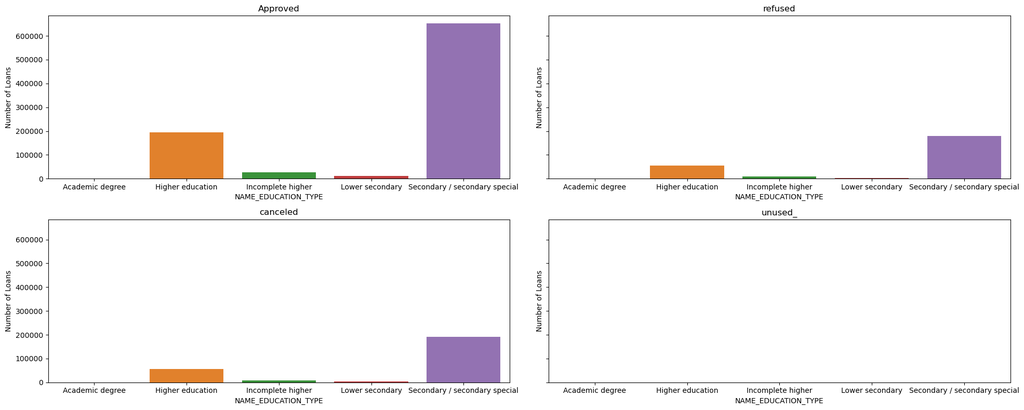

```python
fig,((ax1,ax2),(ax3,ax4)) = plt.subplots(nrows=2,ncols=2,figsize=(20,8),sharey=True)
ax1=sns.countplot(ax=ax1,data=approved_df,x='NAME_EDUCATION_TYPE')
ax1.set_title('Approved')
ax1.set_xlabel('NAME_EDUCATION_TYPE')
ax1.set_ylabel('Number of Loans')
ax2=sns.countplot(ax=ax2,data=refused_df,x='NAME_EDUCATION_TYPE')
ax2.set_title('refused')
ax2.set_xlabel('NAME_EDUCATION_TYPE')
ax2.set_ylabel('Number of Loans')
ax3=sns.countplot(ax=ax3,data=canceled_df,x='NAME_EDUCATION_TYPE')
ax3.set_title('canceled')
ax3.set_xlabel('NAME_EDUCATION_TYPE')
ax3.set_ylabel('Number of Loans')
ax4=sns.countplot(ax=ax4,data=unused_df,x='NAME_EDUCATION_TYPE')
ax4.set_title('unused_')
ax4.set_xlabel('NAME_EDUCATION_TYPE')
ax4.set_ylabel('Number of Loans')
plt.tight_layout()
plt.show()
```

```python
##observation:Secandary special are highly approved aand more refused
```

```python
##visunalizing the 4 plots,we will put the above code in function and generalize the following plot
```

```python
def combined_plots(variable_name):
    fig, ((ax1, ax2), (ax3, ax4)) = plt.subplots(nrows=2,ncols=2, figsize=(20,6), sharey='all')
    fig.tight_layout(pad=10.0)

    ax1 = sns.countplot(ax=ax1,data=approved_df,x=variable_name)
    ax1.set_title("Refused", fontsize=10)
    ax1.set_ylabel("Number of Loans")
    ax1.set_xticklabels(ax1.get_xticklabels(),rotation=90)

    ax2 = sns.countplot(ax=ax2,data=refused_df,x=variable_name)
    ax2.set_title("Approved", fontsize=10)
    ax2.set_ylabel("Number of Loans")
    ax2.set_xticklabels(ax2.get_xticklabels(),rotation=90)

    ax3 = sns.countplot(ax=ax3,data=canceled_df,x=variable_name)
    ax3.set_title("Canceled", fontsize=10)
    ax3.set_xlabel(variable_name)
    ax3.set_ylabel("Number of Loans")
    ax3.set_xticklabels(ax3.get_xticklabels(),rotation=90)

    ax4 = sns.countplot(ax=ax4,data=unused_df,x=variable_name)
    ax4.set_title("Unused", fontsize=10)
    ax4.set_xlabel(variable_name)
    ax4.set_ylabel("Number of Loans")
    ax4.set_xticklabels(ax4.get_xticklabels(),rotation=90)
    plt.tight_layout()
    plt.show()
```

[figure not shown]

```python
combined_plots('NAME_FAMILY_STATUS')
```

#### Final Observation: As checked the married takes more loans, they are more refused and also more approved at the same time

```python
#let talks about teh OCCUPATION_TYPE
```

[figure not shown]

```python
combined_plots('OCCUPATION_TYPE')
```

```python
##conclusion:
```

# 1.Focus on basically the Working Professionals

# 2.Avoid the Housing type with parents as they may lead to defaulters

# 3.As per Gender , should focus on Females as they are more who are highly approved also they are capable to repaying it in comparison with Males

# 4.Should also focus on Studednt as they do not commit to be a defaulters.